# Manual annotation protocol

### Software requirements

Free, open-source and cross-plaform software: Audacity (https://www.audacityteam.org/)

### Step by step procedure

1. Open audio file with Audacity
2. Import labels. The labels should be in the text file. **File -> Import -> Labels**
3. Replace the label number with the soundtype identifier (Figure 1)
4. Save new labels. Save the new text file with a new name. **File -> Export -> Labels**

**Important Notes**:

- The boundaries of the regions of interest were delimited by an automated procedure and might not be always accurate, however, these boundaries should not be modifed manually in order to correctly test the complete system performance.
- When giving a manual label, consider if the sound is at least partially between the temporal limits provided with the label.

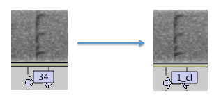

*Figure 1*

### Soundtype identifiers

To have a detailed information about the soundtypes present in the dataset, please use the following notation.

```
[presence or absence]_[type of sound]
```

The absence of calls should have as many soundtypes found in the dataset. I usually have at least two soundtypes:

- **0_clip**: clip produced by branch craking or raindrops
- **0_bg**: constant background with no clear soundtype

Figure 2 present some examples of soundtypes where the sound of interest is the call of *Hypsiboas faber*.

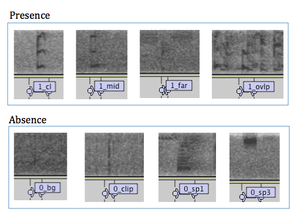

*Figure 2*

### Keyboard shortcuts

Audacity has some useful keyboard shortcuts that can speed up the annotation process. Here a few tricks. **On the label track** use:

- **tab key**: jump to next label
- **shift + tab key**: jump to previous label
- **enter**: selects the audio section corresponding to the label. The section can be played by pressing the **space bar**. To then write the name of the soundtype, press the **tab key**